# Нейронные сети в R

16_04_2019

## R

Для построения нейронных сетей в R потребуется:

- Основы R
- Классы в R (num, int, factor, character)
- Типы данных в R (отличать вектор,массив,матрицу и датафрейм)
- Основы визуализации в R (ggplot2 будет плюсом)
- Основы выборки, генераторы случайных чисел
- Основы линейной алгебры
- Основы статистики, эконометрики, и анализ временных рядов - большой плюс

## Некоторые русскоязычные источники и литература по R

- Кабаков Р. R в действии. Анализ и визуализация данных на языке R. – Litres, 2017.
- Шипунов А. Б. и др. Наглядная статистика. Используем R //М.: ДМК Пресс. – 2012. – Т. 298. – С. 1.
- Шитиков В. К., Мастицкий С. Э. Классификация, регрессия и другие алгоритмы Data Mining с использованием R // https://r-analytics.blogspot.com/
- Анализ данных в R https://www.ADinR.ru, группа в контакте [Анализ данных в R](https://vk.com/adinr)

## Некоторые англоязычные источники и литература по R

- Chambers J. Software for data analysis: programming with R. – Springer Science & Business Media, 2008.
- Matloff N. The art of R programming: A tour of statistical software design. – No Starch Press, 2011.
- Burns P. The R inferno. – Lulu. com, 2011.
- Wickham H., Grolemund G. R for data science: import, tidy, transform, visualize, and model data. – " O'Reilly Media, Inc.", 2016.
- R programming by Johns Hopkins University (Coursera)
- https://www.r-bloggers.com

## Источники нейронные сети

- Chollet F. Deep Learning with R
- Lanz B. Machine Learning with R
- https://www.deeplearningbook.org/
- Курсы от Standford https://www.deeplearning.ai/deep-learning-specialization/ (Coursera)
- Некоторые лекции от MIT http://introtodeeplearning.com/

## Что такое Искусственные нейронные сети?

Искусственные нейронные сети (ANN) или связанные системы - это вычислительные системы, частично вдохновленные биологическими нейронными сетями.

Сама нейронная сеть - это не алгоритм, а скорее структура для множества различных алгоритмов машинного обучения для совместной работы и обработки сложных массивов данных.

## Искусственные нейронные сети

Это модели, которые за счет аппроксимации результатов помогают решать следующие задачи:

- Регрессии
- Классификации
- Распознавания изображений
- Распознавания звука

ANN основан на наборе связанных блоков или узлов, называемых искусственными нейронами, которые слабо моделируют нейроны в биологическом мозге.

Каждое соединение, подобно синапсам в биологическом мозге, может передавать сигнал от одного искусственного нейрона к другому.

Искусственный нейрон, который получает сигнал, может обрабатывать его, а затем сигнализировать о подключении к нему дополнительных искусственных нейронов.

## Нейронные сети

Нейронная сеть является важной частью машинного обучения и может рассматриваться как аналог нервной системы человека.

[Подробное описание нейрона Wiki](https://ru.wikipedia.org/wiki/%D0%9D%D0%B5%D0%B9%D1%80%D0%BE%D0%BD)

Так же, как нервная система человека, которая состоит из взаимосвязанных нейронов, нейронная сеть состоит из взаимосвязанных блоков обработки информации.

Блоки обработки информации не работают линейно. Фактически, нейронная сеть черпает силу в параллельной обработке информации, что позволяет ей справляться с нелинейностью. Нейронная сеть становится удобной, когда появляется задача обнаружить "шаблоны" из сложных и больших наборов данных.

## Библиотеки для нейронных сетей в R

- nnet
- neuralnet
- h2o
- kohonen
- MXNet
- RSNNS
- TensorFlow
- Keras
- NeuralNetTools (дополнительные инструменты для ИНН)

## Персептрон Розенблата

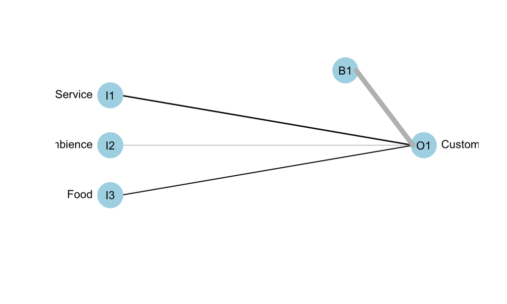

## Нейронные сети - это черные ящики?

Нейронная сеть считается одним из самых полезных методов в мире анализа данных.

Тем не менее, он сложен и часто рассматривается как черный ящик, то есть пользователи просматривают ввод и вывод нейронной сети, но остаются в неведении о процессе генерирования значений и результатов.

## Основные виды нейронных сетей

Почему основные виды?

Потому что на сегодняшних день существует огромное коллическто нейронных сетей. В основном, они являются производными видами или подвидами основных или базисных нейронных сетей

Замечательная [классификация нейронных сетей](http://www.asimovinstitute.org/neural-network-zoo/)

## Классификация

- Feed Forward Neural Network
- Autoencoders
- Boltzman Machines
- Reccurent Neural Network
- Convolutional Neural Network
- Self organising map - Kohonen networks

## Однослойная нейронная сеть

### Однослойный персептрон (one layer perceptron)

краткое описание модели в R Для построения однослойной нейронной сети проще всего использовать библиотеку nnet

```
## a 3-5-1 network with 26 weights
## inputs: Service Ambience Food
## output(s): CustomerWillTip
## options were - decay=0.05
```

## Нейронная сеть 3-5-1

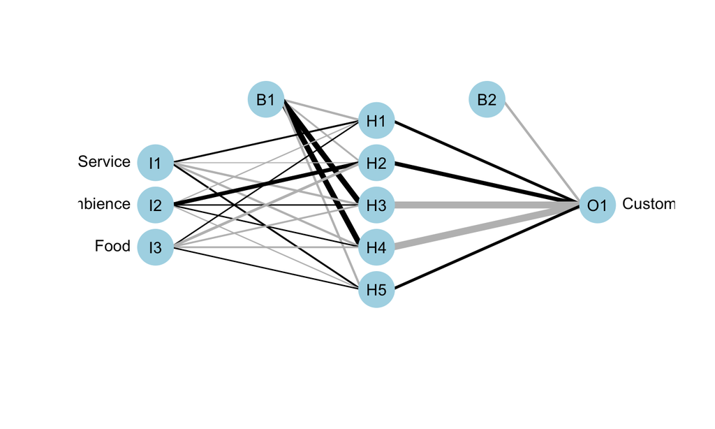

## Многослойная нейронная сеть

### Многослойный персептрон (multi-layer perceptron)

[output not shown]

[output cut: 232 more lines]

[output not shown]

## Многослойная нейронная сеть

### Многослойный персептрон (multi-layer perceptron)

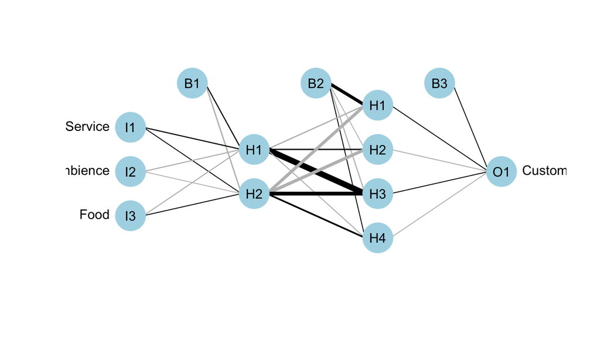

## Deep learning

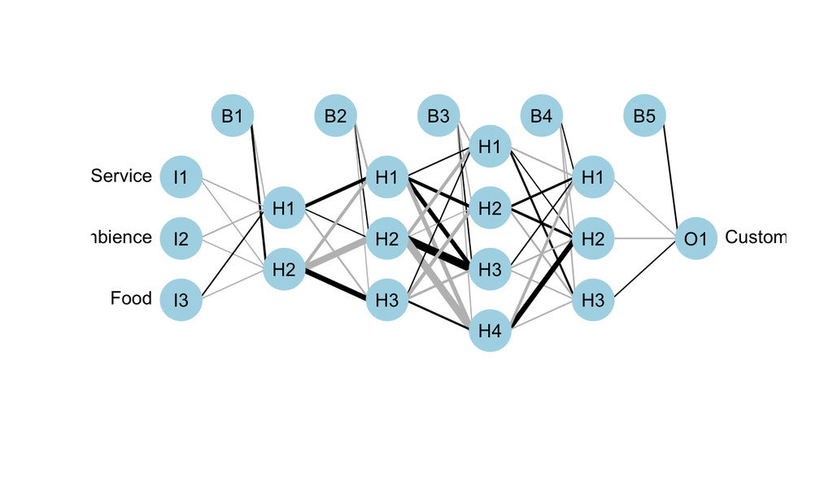